# Australian Demographic Study

# A1 Investigating the distribution of Indigenous Australian

```r
install.packages(c('tidyverse', 'knitr'),repos = "http://cran.us.r-project.org")
```

```r
library(tidyverse)
library(knitr)
```

### A.) What regions have the maximum and minimum total Indigenous populations in 2016 and 2031?

```r
df1 <- read_csv('./Data1.csv')
```

Looking at data frame we see that values of Age column are somewhat inconsistent. For the years 5-9 and 10-14 we have their value as ‘5-Sept’ and ‘Oct-14’. We rectify this by mutating the Age column of df1.

```r
df1 <- df1 %>%
mutate(Age = ifelse(as.character(Age) == 'Oct-14', '10-14', ifelse(as.character(Age) == '5-Sep', '5-9', as.character(Age))))
```

We change the name of Indigenous region column to avoid confusion and make it easier to refer.

```r
colnames(df1)[2] = 'Indigenous_Region_Names'
```

In order to find which region(s) has maximum, minimum population in year 2016 and 2031, we first filter the rows which have value for TIME column as 2016 or 2031. Then we group the df By columns Indigenous_Region_Names and TIME then take summary of value column.

```r
total_pop_by_region <- df1 %>%
filter(TIME==c(2016,2031)) %>%
group_by(Indigenous_Region_Names, TIME) %>%
summarise(pop=sum(Value))
```

After having gotten population value for each region by year 2016 and 2031, we filter the rows which represent either the max population or minimum population.

```r
total_pop_by_region %>%
group_by(TIME) %>%
filter(pop == max(pop) | pop == min(pop)) %>%
kable(caption = 'Regions with max/min population')
```

Regions with max/min population

| Indigenous_Region_Names | TIME | pop |
| --- | --- | --- |
| Brisbane | 2031 | 129835 |
| NSW Central and North Coast | 2016 | 85169 |
| Port Lincoln - Ceduna | 2016 | 2738 |
| Port Lincoln - Ceduna | 2031 | 2881 |

### B.) What region/s have the maximum and minimum growth or decay rates of their total Indigenous population between 2016 and 2031?

We already have population data for year 2016 and 2031 for all regions but its in wrong format. Now we’ll tidy the df by applying pivot wider to make values of column TIME itself columns.

```r
pop_by_region_year <- total_pop_by_region %>%
pivot_wider(names_from = TIME, values_from = pop)
```

Now we mutate columns 2016 and 2031 to create a new rate column to find growth/decay rates of all regions. Note that positive values in rate column mean growth and negative rate means decay.

```r
pop_by_region_year <- pop_by_region_year %>%
mutate(rate = 100*(`2031` - `2016`)/(`2016`))
```

Now we filter the modified df to find states with max rate(max-growth) and min rate(max-decay).

```r
pop_by_region_year %>%
ungroup() %>%
filter(rate == max(rate) | rate == min(rate)) %>%
kable(caption = 'States with highest growth/decay rates.')
```

States with highest growth/decay rates.

| Indigenous_Region_Names | 2016 | 2031 | rate |
| --- | --- | --- | --- |
| ACT | 7513 | 11638 | 54.904832 |
| Katherine | 11063 | 10105 | -8.659496 |

### C.) Plot and describe the growth or decay of the total Indigenous populations for the capitals of the 8 state/territories across all time periods.

We first create a character vector with all state capitals.

```r
capitals = c('Melbourne', 'Sydney - Wollongong', 'Brisbane', 'Adelaide', 'Perth', 'Tasmania', 'Darwin', 'ACT')
```

Now we filter df1 to only have rows which have column values matching with capitals vector. Then we summarise the populations of these cities by City and Year values.

```r
total_pop_by_region_year <- df1 %>%
filter(Indigenous_Region_Names %in% capitals) %>%
select(Indigenous_Region_Names,Age, TIME, Value) %>%
group_by(Indigenous_Region_Names, TIME) %>%
summarise(Value = sum(Value)) %>%
ungroup()
```

Now we bring the df to our desired format to every year having its own column, so that its easier to calculate growth/decay rates.

```r
(capital_total_pop <- total_pop_by_region_year %>%
pivot_wider(names_from = TIME, values_from = Value))
```

```
## # A tibble: 8 x 17
##   Indigenous_Regi… `2016` `2017` `2018` `2019` `2020` `2021` `2022` `2023`
##   <chr>             <dbl>  <dbl>  <dbl>  <dbl>  <dbl>  <dbl>  <dbl>  <dbl>
## 1 ACT                7513   7730   7956   8189   8431   8680   8936   9201
## 2 Adelaide          30124  30882  31670  32486  33337  34220  35133  36075
## 3 Brisbane          84454  86869  89369  91956  94626  97384 100230 103169
## 4 Darwin            18309  18544  18781  19017  19255  19495  19737  19985
## 5 Melbourne         28584  29241  29927  30645  31396  32179  32997  33855
## 6 Perth             38919  39929  40963  42034  43143  44287  45472  46694
## 7 Sydney - Wollon…  81685  83001  84388  85849  87381  88982  90657  92409
## 8 Tasmania          28537  29040  29561  30100  30658  31237  31838  32458
## # … with 8 more variables: `2024` <dbl>, `2025` <dbl>, `2026` <dbl>,
## #   `2027` <dbl>, `2028` <dbl>, `2029` <dbl>, `2030` <dbl>, `2031` <dbl>
```

After pivoting the df wider, we apply nested loops which iterate through every column value for each row to calculate and replace it by that and following years’ growth/decay rate.

```r
for(i in 1:nrow(capital_total_pop)){
    for(j in 3:ncol(capital_total_pop)){
        capital_total_pop[[i,j-1]] <- 100*(capital_total_pop[[i,j]] - capital_total_pop[[i,j-1]])/(capital_total_pop[[i,j-1]])
    }
}
capital_total_pop
```

```
## # A tibble: 8 x 17
##   Indigenous_Regi… `2016` `2017` `2018` `2019` `2020` `2021` `2022` `2023`
##   <chr>             <dbl>  <dbl>  <dbl>  <dbl>  <dbl>  <dbl>  <dbl>  <dbl>
## 1 ACT                2.89   2.92   2.93   2.96   2.95   2.95   2.97   2.97
## 2 Adelaide           2.52   2.55   2.58   2.62   2.65   2.67   2.68   2.69
## 3 Brisbane           2.86   2.88   2.89   2.90   2.91   2.92   2.93   2.93
## 4 Darwin             1.28   1.28   1.26   1.25   1.25   1.24   1.26   1.24
## 5 Melbourne          2.30   2.35   2.40   2.45   2.49   2.54   2.60   2.63
## 6 Perth              2.60   2.59   2.61   2.64   2.65   2.68   2.69   2.71
## 7 Sydney - Wollon…   1.61   1.67   1.73   1.78   1.83   1.88   1.93   1.97
## 8 Tasmania           1.76   1.79   1.82   1.85   1.89   1.92   1.95   1.97
## # … with 8 more variables: `2024` <dbl>, `2025` <dbl>, `2026` <dbl>,
## #   `2027` <dbl>, `2028` <dbl>, `2029` <dbl>, `2030` <dbl>, `2031` <dbl>
```

Since we can sum up value of 16 years in 15 cols we ditch year 2031.

```r
capital_total_pop <- subset(capital_total_pop, select = -`2031`)
```

Now that we have the required data, we again pivot longer so that its easier to visualise.

```r
(tidy_df <- capital_total_pop %>%
pivot_longer(-1, names_to = 'year'))
```

```
## # A tibble: 120 x 3
##    Indigenous_Region_Names year  value
##    <chr>                   <chr> <dbl>
##  1 ACT                     2016   2.89
##  2 ACT                     2017   2.92
##  3 ACT                     2018   2.93
##  4 ACT                     2019   2.96
##  5 ACT                     2020   2.95
##  6 ACT                     2021   2.95
##  7 ACT                     2022   2.97
##  8 ACT                     2023   2.97
##  9 ACT                     2024   2.99
## 10 ACT                     2025   2.99
## # … with 110 more rows
```

We notice that the values of newly created year column are characters so we convert them into numeric so it’ll help us in visualisation.

```r
tidy_df <- tidy_df %>% mutate(year = parse_number(year))
```

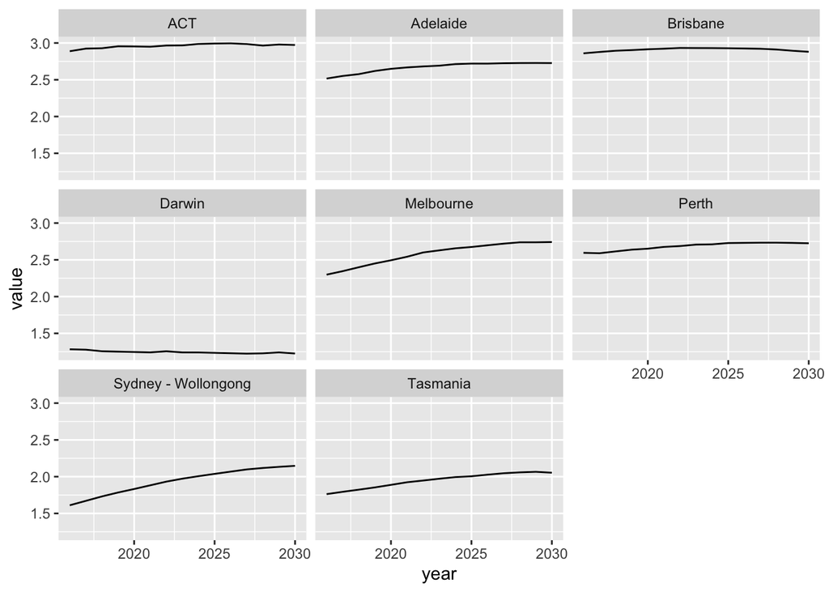

```r
tidy_df %>% ggplot(mapping = aes(x=year, y=value, group=1)) + geom_line() + facet_wrap(~Indigenous_Region_Names)
```

# A2. Investigating the Ages of Indigenous Australians

### 1.) Using Data1, which region has the highest percentage of children in its total 2016 population?

To calculate highest percentage of children population in year 2016, we first calculate popultion of all regions in year 2016.

```r
region_total_pop_16 <- df1 %>%
filter(TIME == 2016) %>%
group_by(Indigenous_Region_Names) %>%
summarise(total_pop = sum(Value))
```

Now we calculate children’s population (<15 years) of all regions in year 2016.

```r
region_child_pop_16 <- df1 %>%
filter(TIME == 2016, Age %in% c('0 - 4', '5-9', '10-14')) %>%
group_by(Indigenous_Region_Names) %>%
summarise(children_pop = sum(Value))
```

Now we take newly created children_pop column from region_child_pop_16 df and append it to region_total_pop_16 df.

```r
region_total_pop_16['child_pop'] <- region_child_pop_16$children_pop
```

Now we create a new column named percent_child which lists total percent of children population in each region and from that filter the region with max percentage.

```r
region_total_pop_16 %>%
mutate(percent_child = (child_pop/total_pop)*100) %>%
filter(percent_child == max(percent_child)) %>%
kable(caption = 'State with highest percent of children population.')
```

State with highest percent of children population.

| Indigenous_Region_Names | total_pop | child_pop | percent_child |
| --- | --- | --- | --- |
| Toowoomba - Roma | 21350 | 8489 | 39.76112 |

### 2.) which state or territory has the highest percentage of children in its total 2006, 2016 and 2031 populations.

```r
df2 <- read_csv('./Data2.csv')
```

To calculate state/territory with highest children population in years 2006,2016,2031 we first calculate children population of all states in prescribed years.

```r
(child_pop_by_state <- df2 %>%
select('State','Age','2006', '2016', '2031') %>%
filter(Age %in% c('0','1','2','3','4','5','6','7','8','9','10','11','12','13','14')) %>%
group_by(State) %>%
summarise(child_total_06 = sum(`2006`),child_total_16 = sum(`2016`),child_total_31 = sum(`2031`)))
```

```
## # A tibble: 8 x 4
##   State child_total_06 child_total_16 child_total_31
##   <chr>          <dbl>          <dbl>          <dbl>
## 1 ACT             2317           2389           3107
## 2 NSW            80316          92615         112502
## 3 NT             20263          22127          20563
## 4 QLD            69861          79410          96730
## 5 SA             13477          14506          17292
## 6 Tas             8465           9721          10796
## 7 Vic            18072          19920          26095
## 8 WA             29935          33583          38318
```

Now we calculate total population of these states in aforementioned years.

```r
(total_pop_by_state <- df2 %>%
select('State', 'Age', '2006', '2016', '2031') %>%
group_by(State) %>%
summarise(total_06 = sum(`2006`), total_16 = sum(`2016`), total_31 = sum(`2031`)))
```

```
## # A tibble: 8 x 4
##   State total_06 total_16 total_31
##   <chr>    <dbl>    <dbl>    <dbl>
## 1 ACT       6274     7513    11324
## 2 NSW     207786   265685   354771
## 3 NT       61686    74546    88170
## 4 QLD     175267   221276   304395
## 5 SA       34681    42265    57306
## 6 Tas      22881    28537    37089
## 7 Vic      48093    57767    83606
## 8 WA       83130   100512   134895
```

Now we append 2006,2016 and 2031 population columns from child df to total population df.

```r
total_pop_by_state[c('child_total_06', 'child_total_16', 'child_total_31')] <- child_pop_by_state[c('child_total_06', 'child_total_16', 'child_total_31')]
```

Now we create new child percent columns by manipulating existing columns and filter the rows with values which are either highest in 2006,2016 or 2031 column.

```r
total_pop_by_state %>%
transmute(State, percent_2006 = 100 * child_total_06/total_06, percent_2016 = 100 * child_total_16/total_16, percent_2031 = 100 * child_total_31/total_31) %>%
filter(percent_2006 == max(percent_2006) | percent_2016 == max(percent_2016) | percent_2031 == max(percent_2031)) %>%
kable(caption = 'States with highest percentage of child population in total population.')
```

States with highest percentage of child population in total population.

| State | percent_2006 | percent_2016 | percent_2031 |
| --- | --- | --- | --- |
| QLD | 39.85976 | 35.88731 | 31.77779 |

### 3.) Use R to build a Motion Chart comparing the total Indigenous Australian population of each region to the percentage of Indigenous Australian children in each state/territory.

```r
install.packages('googleVis',repos = "http://cran.us.r-project.org")
```

```r
library(googleVis)
```

Motion chart compares total population of each region to percentage of children population in each states. First we calculate total population of each region by year.

```r
(region_total_pop_16_to_31 <- df1 %>% group_by(Indigenous_Region_Names, TIME) %>% summarise(pop = sum(Value)))
```

```
## # A tibble: 592 x 3
## # Groups:   Indigenous_Region_Names [37]
##    Indigenous_Region_Names  TIME   pop
##    <chr>                   <dbl> <dbl>
##  1 ACT                      2016  7513
##  2 ACT                      2017  7730
##  3 ACT                      2018  7956
##  4 ACT                      2019  8189
##  5 ACT                      2020  8431
##  6 ACT                      2021  8680
##  7 ACT                      2022  8936
##  8 ACT                      2023  9201
##  9 ACT                      2024  9474
## 10 ACT                      2025  9757
## # … with 582 more rows
```

We have predicted population data from year 2006 to 2031 but since the data for total population of region is only available from year 2016, we will take predicted population data of states from year 2016 as well. The states population data is not in same format as the regional population data, therefore we’ll use pivot longer to bring them into same format and calculate states total population for each year from 2016 to 2031.

```r
(states_total_pop_16_to_31 <- df2 %>%
arrange(State) %>%
select(1,2,13:28) %>%
pivot_longer(-c(1,2), names_to = 'Year') %>%
group_by(State, Year) %>%
summarise(total = sum(value)))
```

```
## # A tibble: 128 x 3
## # Groups:   State [8]
##    State Year  total
##    <chr> <chr> <dbl>
##  1 ACT   2016   7513
##  2 ACT   2017   7728
##  3 ACT   2018   7949
##  4 ACT   2019   8178
##  5 ACT   2020   8414
##  6 ACT   2021   8653
##  7 ACT   2022   8897
##  8 ACT   2023   9147
##  9 ACT   2024   9402
## 10 ACT   2025   9662
## # … with 118 more rows
```

Now we calculate states children’s population data in the same way as above and also add an additional filter to include rows with Age<15.

```r
(states_child_pop_16_to_31 <- df2 %>%
arrange(State) %>%
select(1,2,13:28) %>%
filter(Age %in% c('0','1','2','3','4','5','6','7','8','9','10','11','12','13','14')) %>%
pivot_longer(-c(1,2), names_to = 'year', values_to = 'pop') %>%
group_by(State, year) %>%
summarise(pop = sum(pop)))
```

```
## # A tibble: 128 x 3
## # Groups:   State [8]
##    State year    pop
##    <chr> <chr> <dbl>
##  1 ACT   2016   2389
##  2 ACT   2017   2414
##  3 ACT   2018   2443
##  4 ACT   2019   2482
##  5 ACT   2020   2528
##  6 ACT   2021   2570
##  7 ACT   2022   2624
##  8 ACT   2023   2677
##  9 ACT   2024   2718
## 10 ACT   2025   2742
## # … with 118 more rows
```

Now we add states children pop column to states total pop df in order to calculate children percent population from year 2016 to 2031.

```r
states_total_pop_16_to_31['total child pop'] <- states_child_pop_16_to_31['pop']
```

Now we calculate percent children pop for each state for each year from 2016 to 2031

```r
(states_child_percent_16_to_31 <- states_total_pop_16_to_31 %>%
group_by(State, Year) %>%
summarise('percent child' = 100*(`total child pop`)/`total`))
```

```
## # A tibble: 128 x 3
## # Groups:   State [8]
##    State Year  `percent child`
##    <chr> <chr>           <dbl>
##  1 ACT   2016             31.8
##  2 ACT   2017             31.2
##  3 ACT   2018             30.7
##  4 ACT   2019             30.3
##  5 ACT   2020             30.0
##  6 ACT   2021             29.7
##  7 ACT   2022             29.5
##  8 ACT   2023             29.3
##  9 ACT   2024             28.9
## 10 ACT   2025             28.4
## # … with 118 more rows
```

Now we have region population data for years as well as states child percent population data but in order to make any sense out of these two we need to first find a way to connect these two df together so that we can draw further conclusions i.e. assign each region a state and its corresponding child percent population data. Therefore we create a vector containing states names to which region belong in the same order as they appear in regional data.

```r
states_vec <- c('ACT', 'SA', 'NT', 'NT', 'QLD', 'WA','QLD','QLD', 'NT', 'NSW', 'WA', 'NT', 'WA', 'NT', 'WA', 'Vic', 'QLD', 'NT', 'NSW','NSW','NSW','WA','SA', 'SA', 'NSW', 'QLD', 'WA', 'NSW', 'WA', 'NSW', 'Tas', 'NT', 'QLD','QLD','QLD','Vic','WA')
```

Now we know that regional data contains population value of each region from year 2016 to 2031 i.e. 16 years and since it is sorted by region names in alphabetical order we repeat each value in states vector 16 times to match their dimensions.

```r
states_vec <- rep(states_vec, each = 16)
```

We add states vector as a column to regional data.

```r
region_total_pop_16_to_31['State'] <- states_vec
```

We change column name in regional data so that we can merge the two dfs.

```r
colnames(region_total_pop_16_to_31)[2] <- 'Year'
```

Now we merge regional data df with states data df based on Year and state column values.

```r
merged_df <- merge(region_total_pop_16_to_31, states_child_percent_16_to_31, by = c('Year', 'State')) %>%
arrange(State)
head(merged_df)
```

```
##   Year State Indigenous_Region_Names  pop percent child
## 1 2016   ACT                     ACT 7513      31.79822
## 2 2017   ACT                     ACT 7730      31.23706
## 3 2018   ACT                     ACT 7956      30.73343
## 4 2019   ACT                     ACT 8189      30.34972
## 5 2020   ACT                     ACT 8431      30.04516
## 6 2021   ACT                     ACT 8680      29.70068
```

Now we create a motion chart with region names as id vars and Year as time var.

```r
motion_chart = gvisMotionChart(merged_df, idvar = 'Indigenous_Region_Names', timevar = 'Year', sizevar = 'pop', colorvar = 'State')
plot(motion_chart)
```

Note that motion chart can’t be shown in .Rmd documents. In order to see the motion chart open this document in R studio and then manually run it.

### 4.) Using the Motion Chart, answer the following questions

#### A.) Which region’s population overtakes that of another region in the same state/territory? In which year/s does this happen?

As per our findings, no regions population overtakes any other regions population which belongs to same state as the former. However some comes close but no one ever overtakes.

#### B.) Is there generally a relationship between the Indigenous Australian population size and percentage of children in the population? If so, what kind of relationship?

We see from the motion graph that as the population of a region increases we see a decline in percent child population of that region.

#### C.) Colour is commonly used in data visualisation to help understand data. Which aspect of this data would you use colour for in your plot and why?

We used state variable to color the observations as it makes it easy for us to interpret the graph and helps understand the how change in one variable reflects in another variable for all regions belonging to same state.

#### D.) Are there any other interesting things you notice in the data or any changes you would recommend for the Motion Chart?

For cities with lower population i.e. < 20000 we see that as the time progress, there’s a substantial decrease in child percent in total population but no noteworthy increase in total population whatsoever. I.e. for the State of Northern Territory, we see that in 2016 children percent in total pop was approximately 30% whereas in 2031, it falls down to be 23% which almost negligible increase in population.

# B1 - Investigating the Ages of Indigenous Australians (Values and Variables)

```r
library(tidyverse)
```

```r
df3 <- read_csv('./Data3.csv')
```

Remove extra columns at the very right.

```r
df3 <- subset(df3, select = -c(X13, X14, X15, X16))
```

We see that rows containing Indigenous Australian values are of data type character. So we convert them into numeric. Upon further investigation we find that some missing data was present in this column but instead of having NA as their value, it was NP.

```r
df3 <- df3 %>% mutate(`Number of registered IndigAus  children` = parse_number(`Number of registered IndigAus  children`),
`Number IndigAus fully immunised` = parse_number(`Number IndigAus fully immunised`),
`Number IndigAus not fully immunised` = parse_number(`Number IndigAus not fully immunised`))
```

### 1.) How many PHN areas does the data cover?

```r
length(unique(df3$`PHN area name`))
```

```
## [1] 31
```

### 2.) What are the possible values for ‘PHN code’?

```r
unique(df3$`PHN code`)
```

```
##  [1] "PHN801" "PHN103" "PHN107" "PHN106" "PHN101" "PHN109" "PHN105" "PHN110"
##  [9] "PHN104" "PHN108" "PHN102" "PHN701" "PHN306" "PHN305" "PHN302" "PHN307"
## [17] "PHN304" "PHN303" "PHN301" "PHN401" "PHN402" "PHN601" "PHN202" "PHN204"
## [25] "PHN201" "PHN203" "PHN206" "PHN205" "PHN501" "PHN502" "PHN503"
```

### 3.) For each row, calculate the percentage of Australian children that are fully immunised (this is the immunisation rate). What are the average, maximum and minimum immunisation rates? Calculate the same for the group that are Indigenous Australian children.

In order to find immunistaion rates, we create two new columns by modifying existing columns. For rows with missing values, we exclude those rows.

```r
(immunisation_rates_df <- df3 %>%
mutate(immunisation_rate = 100*(`Number fully immunised`)/`Number of registered children`,
indig_immunisation_rates = 100*(`Number IndigAus fully immunised`)/`Number of registered IndigAus  children`,
na.exclude = T) %>%
subset(select = -c(na.exclude)))
```

```
## # A tibble: 465 x 14
##    State `PHN code` `PHN area name` `Reporting Year` `Age group`
##    <chr> <chr>      <chr>           <chr>            <chr>
##  1 ACT   PHN801     Australian Cap… 2015-16          2 years
##  2 ACT   PHN801     Australian Cap… 2014-15          2 years
##  3 ACT   PHN801     Australian Cap… 2016-17          2 years
##  4 ACT   PHN801     Australian Cap… 2012-13          1 year
##  5 ACT   PHN801     Australian Cap… 2013-14          1 year
##  6 ACT   PHN801     Australian Cap… 2012-13          2 years
##  7 ACT   PHN801     Australian Cap… 2015-16          5 years
##  8 ACT   PHN801     Australian Cap… 2012-13          5 years
##  9 ACT   PHN801     Australian Cap… 2014-15          1 year
## 10 ACT   PHN801     Australian Cap… 2015-16          1 year
## # … with 455 more rows, and 9 more variables: `Number of registered
## #   children` <dbl>, `Number fully immunised` <dbl>, `Number not fully
## #   immunised` <dbl>, `Number of registered IndigAus children` <dbl>, `Number
## #   IndigAus fully immunised` <dbl>, `Number IndigAus not fully
## #   immunised` <dbl>, `Interpret with caution (#)` <chr>,
## #   immunisation_rate <dbl>, indig_immunisation_rates <dbl>
```

From the processed data frame, we now calculate mean/max/min immunisation rates for both indigenous and all australian children.

```r
immunisation_rates_df %>%
summarise(avg_immunisation_rate = mean(immunisation_rate),
max_im_rate = max(immunisation_rate),
min_im_rate = min(immunisation_rate),
avg_indig_im_rate = mean(indig_immunisation_rates, na.rm = T),
max_indig_im_rate = max(indig_immunisation_rates, na.rm = T),
min_indig_im_rate = min(indig_immunisation_rates, na.rm = T)) %>%
kable(caption = 'Max/Min/Mean Immunisation rates')
```

Max/Min/Mean Immunisation rates

| avg_immunisation_rate | max_im_rate | min_im_rate | avg_indig_im_rate | max_indig_im_rate | min_indig_im_rate |
| --- | --- | --- | --- | --- | --- |
| 92.06154 | 96.15255 | 86.09929 | 89.92436 | 97.68977 | 73.77049 |

# B2.) Variation in rates over Time, Age and Location

Overall Immunisation rate VS Age and Year

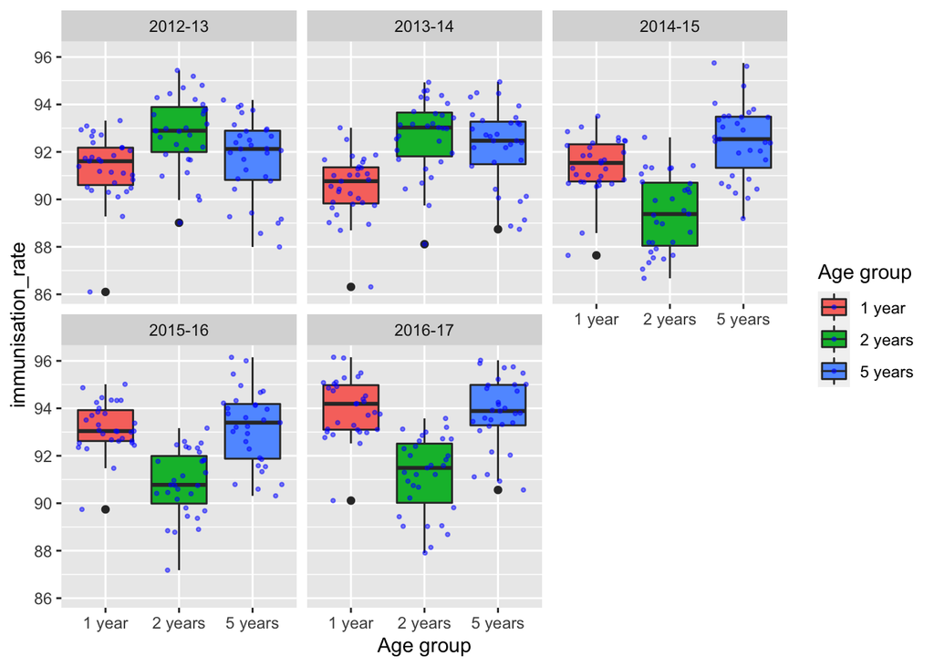

```r
ggplot(data=immunisation_rates_df, mapping = aes(x = `Age group`, y = `immunisation_rate`, fill=`Age group`)) +
geom_boxplot() +
facet_wrap(~`Reporting Year`) +
geom_jitter(color="blue", size=0.7, alpha=0.5)
```

Indigenous Immunisation rates VS Age and Year

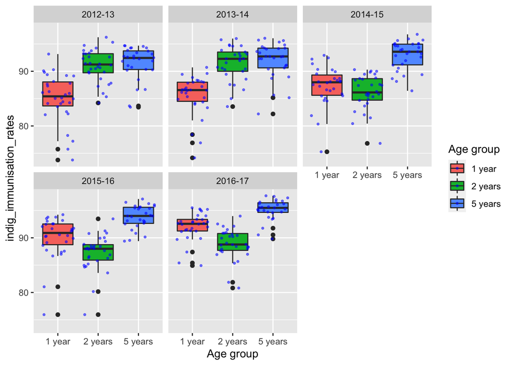

```r
ggplot(data=immunisation_rates_df, mapping = aes(x = `Age group`, y = `indig_immunisation_rates`, fill=`Age group`)) +
geom_boxplot() +
facet_wrap(~`Reporting Year`) +
geom_jitter(color="blue", size=0.7, alpha=0.5)
```

### 1.) Have the immunisation rates improved over time? Are the median immunisation rates increasing, decreasing or staying the same?

Looking at the box plot we confirm that overall immunisation rates have improved for both Indigenous and all australian children.

### 2.) How do the immunisation rates vary with the age of the child?

Overall Immunisation rate vs Area and State

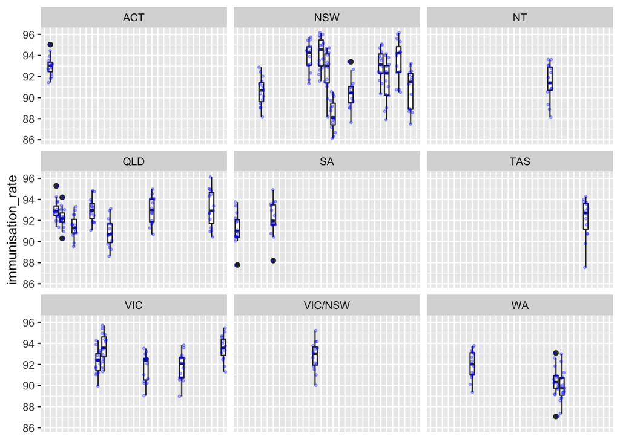

```r
immunisation_rates_df %>%
group_by(`State`,`PHN area name`) %>%
ggplot(mapping = aes(x = `PHN area name`, y = `immunisation_rate`)) +
geom_boxplot() +
facet_wrap(~`State`) +
geom_jitter(color="blue", size=0.7, alpha=0.3) +
theme(legend.position = "none") +
theme(axis.title.x=element_blank(),
        axis.text.x=element_blank(),
        axis.ticks.x=element_blank())
```

Indigenous Immunisation rate vs Area and State

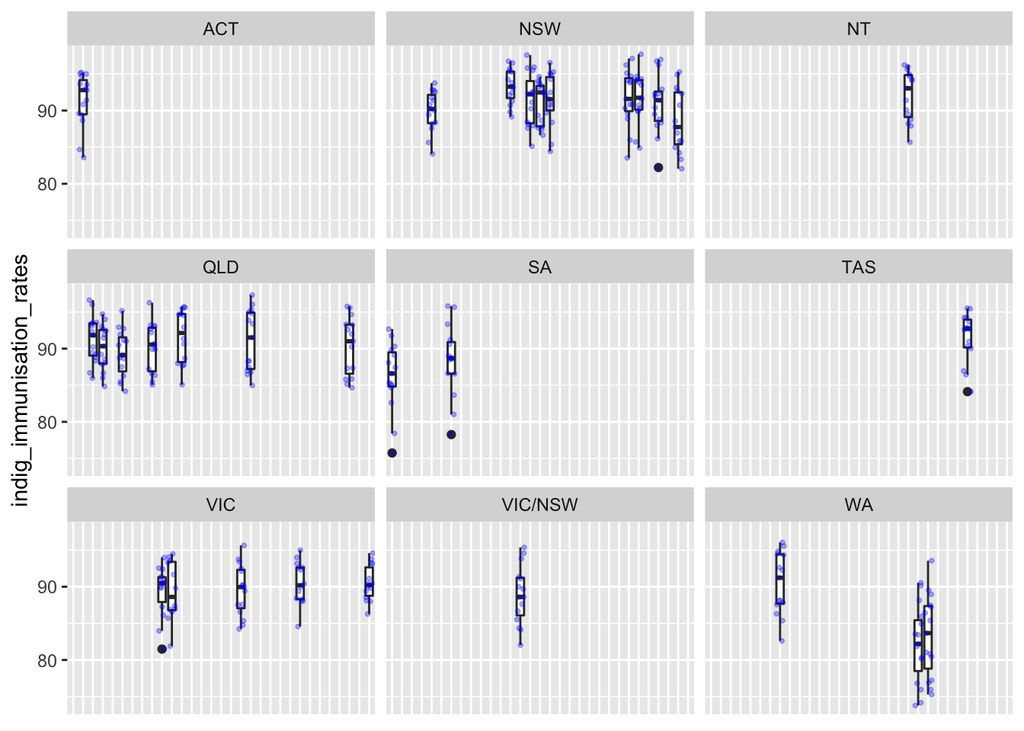

```r
immunisation_rates_df %>%
group_by(`State`,`PHN area name`) %>%
ggplot(mapping = aes(x = `PHN area name`, y = `indig_immunisation_rates`)) +
geom_boxplot() +
facet_wrap(~`State`) +
geom_jitter(color="blue", size=0.7, alpha=0.3) +
theme(legend.position = "none") +
theme(axis.title.x=element_blank(),
        axis.text.x=element_blank(),
        axis.ticks.x=element_blank())
```

### 3.) What is the median rate per state/territory?

```r
immunisation_rates_df %>%
select(1,2,3,4,13,14) %>%
group_by(`State`) %>%
summarise('imm rate'= median(immunisation_rate), 'indig imm rate' = median(indig_immunisation_rates)) %>%
kable(caption = 'Median immunisation rates per territory')
```

Median immunisation rates per territory

| State | imm rate | indig imm rate |
| --- | --- | --- |
| ACT | 93.01651 | 92.79279 |
| NSW | 92.24214 | NA |
| NT | 91.40182 | 93.03843 |
| QLD | 92.39524 | NA |
| SA | 91.66372 | 88.26747 |
| TAS | 92.71472 | 92.71845 |
| VIC | 92.59771 | NA |
| VIC/NSW | 93.02487 | 88.61284 |
| WA | 90.77603 | 85.94249 |

### 4.) Which states or territories seem most consistent in their immunisation rates?

```r
immunisation_rates_df %>% select(1,2,3,4,13,14) %>%
group_by(`State`, `PHN area name`) %>%
arrange(State, `PHN area name`) %>%
summarise('imm rate'= median(immunisation_rate, na.rm = T), 'indig imm rate' = median(indig_immunisation_rates, na.rm = T))
```

```
## # A tibble: 31 x 4
## # Groups:   State [9]
##    State `PHN area name`                      `imm rate` `indig imm rate`
##    <chr> <chr>                                     <dbl>            <dbl>
##  1 ACT   Australian Capital Territory               93.0             92.8
##  2 NSW   Central and Eastern Sydney                 90.7             90.2
##  3 NSW   Hunter New England and Central Coast       94.2             93.3
##  4 NSW   Murrumbidgee                               94.6             92.2
##  5 NSW   Nepean Blue Mountains                      93.0             92.5
##  6 NSW   North Coast                                88.1             91.6
##  7 NSW   Northern Sydney                            90.4             NA
##  8 NSW   South Eastern NSW                          93.1             91.6
##  9 NSW   South Western Sydney                       92.3             91.7
## 10 NSW   Western NSW                                94.2             91.4
## # … with 21 more rows
```